# Convex Sets and convex Functions

Marcel Angenvoort

2025-07-01

## Convex Sets

Before we start with optimisation algorithms, we first need to introduce some concepts.

**Convex Set**

A set $M$ is called **convex** if for any $\mathbf{x}_1, \mathbf{x}_2 \in M$:
$$\theta \mathbf{x}_1 + (1-\theta) \mathbf{x}_2 \in M
\qquad \forall \theta \in [0, 1]$$

In other words, a set is convex if any line connecting two of its points is also contained within the set.

[figure not shown]

**convex set**  
source: [wikimedia.org](https://commons.wikimedia.org/wiki/File:Convex_polygon_illustration1.svg) license: [CC BY-SA 4.0](https://creativecommons.org/licenses/by-sa/4.0/)

[figure not shown]

**nonconvex set**  
source: [wikimedia.org](https://commons.wikimedia.org/wiki/File:Convex_polygon_illustration2.svg) license: [CC BY-SA 4.0](https://creativecommons.org/licenses/by-sa/4.0/)

Figure 1: Examples for convex and nonconvex sets

The expression $\theta \mathbf{x}_1 + (1-\theta) \mathbf{x}_2$ is called an **convex-combination**.

This can be generalized to more than two points. Let’s say we have multiple points $x_1, \dotsc, x_n$, then we have
$$\sum_{i=1}^n \theta_i \mathbf{x}_i \in M$$
where
$$\theta_i \ge 0 \quad \forall 1 \leq i \leq n, \quad \sum_{i=1}^n \theta_i = 1.$$

For anyone familiar with statistics, this will look very similar to the expectation of a probability distribution.

And indeed, this can be generalised to continuous functions: Suppose $p(\mathbf{x})$ satisfies $p(\mathbf{x}) \gt 0$ and
$$\int_M p(\mathbf{x}) \, \mathrm{d}\mathbf{x} = 1,$$
then
$$\int_M p(\mathbf{x}) \mathbf{x} \, \mathrm{d}\mathbf{x} \in M.$$

In other words, the expectation value must be within the convex set.

### Examples for convex sets:

1. Simplices:
   $$S = \left\{
   \mathbf{x} \in \mathbb{R}^n: \exists \theta_1, \dotsc, \theta_n \in [0, 1], \, \textstyle\sum_{i=1}^n \displaystyle \theta_i = 1 : \mathbf{x} = \sum_{i=1}^n \theta_i \mathbf{v}_i
   \right\}$$
2. Polyhedra
   $$P = \Bigl\{
   \mathbf{x} \in \mathbb{R}^n : \mathbf{a}_j^\mathrm{T} \mathbf{x} \leq b_j, \, \mathbf{c}_k^\mathrm{T} \mathbf{x} = d_k, \, j=1,\dotsc, m, \, k=1,\dotsc,p
   \Bigr\}$$

[figure not shown]

**Simplex**  
author: *Robert Webb*  
source: [wikimedia.org](https://commons.wikimedia.org/wiki/File:Tetrahedron.png) url: [Stella software](https://www.software3d.com/Stella.php)

[figure not shown]

**Polyhedron**  
author: *Tilman Piesk*  
source: [wikimedia.org](https://commons.wikimedia.org/wiki/File:Polyhedron_12-20_max.png) license: [CC BY-SA 4.0](https://creativecommons.org/licenses/by-sa/4.0/)

Figure 2: Simplices and Polyhedra are examples for convex sets.

### Operations that preserve Convexity

- **Intersection**: If $A$ and $B$ are convex, then the intersection
  $$A \cap B$$
  is also convex.
- **affine Transformations**: If $M$ is a convex set and $f:\mathbb{R}^n \to \mathbb{R}^n$ is an affine transformation, i.e. $f(\mathbf{x}) = A \mathbf{x} + \mathbf{b}$, then the image
  $$f(M)$$
  is also convex.
- The *projection* of a convex set onto some of it’s coordinates is convex: If $S \subseteq \mathbb{R}^m \times \mathbb{R}^n$, then
  $$T = \{ x_1 \in \mathbb{R}^m | (x_1, x_2) \in S \;\text{for some $x_2 \in \mathbb{R}^n$} \}$$
  is convex.(Boyd and Vandenberghe 2004)

As a simple corollary, we can see that the perspective function $f: \mathbb{R}^n \times \mathbb{R}^+$,
$$f(\mathbf{x}, t) = \frac{\mathbf{x}}{t}$$
preserves convexity.

Visually, we can interpret the perspective function as a pinhole camera.

### The Separating Hyperplane Theorem

**Separating Hyperplane Theorem**

Suppose $A$ and $B$ are non-empty, disjoint sets, i.e. $A \cap B = \emptyset$. Then there exists $\mathbf{a} \ne \mathbf{0}$ and $b$ such that $\mathbf{a}^\mathrm{T} \mathbf{x} \leq b$ for all $\mathbf{x} \in A$ and $b \leq \mathbf{a}^\mathrm{T} \mathbf{x}$ for all $\mathbf{x} \in B$.

[figure not shown]

Figure 3: **Separating Hyperplane Theorem**  
author: *Oleg Alexandrov*  
source: [Wikimedia](https://commons.wikimedia.org/wiki/File:Separating_axis_theorem_20080107.svg) license: [public domain (CC0)](https://creativecommons.org/publicdomain/zero/1.0/)

*Proof*. See notes.

**Note**

This result can be generalized to the **Hahn-Banach separation theorem**.

## Convex Functions

**Convex functions**

Let $D$ be a convex set. A function $f: D \to \mathbb{R}$ is called **convex** if
$$f\bigl(\theta \mathbf{x}_1 + (1-\theta) \mathbf{x}_2\bigr) \leq \theta f(\mathbf{x}_1) + (1-\theta) f(\mathbf{x}_2), \qquad \theta \in [0, 1]$$

Visually, this means that the graph between two points always lies below the secant line connecting them.

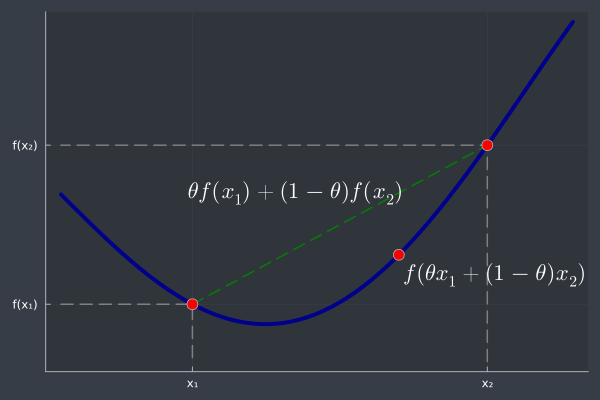

Figure 4: A convex function

```julia
using Plots
using LaTeXStrings
theme(:dark)
#default(size = (800, 600))  # set default plot size

# Define objective function f
f(x) = -0.01548523*x^4 + 0.09320228*x^3 + 0.21426876*x^2 + -0.83797152*x + 0.90722445

xmin = -0.654
xmax = 4.074
x = range( xmin, xmax, length=100)

x1 = 0.56
x2 = 3.284
theta = 0.3
x_comb = theta * x1 + (1 - theta) * x2

# Plot function f
plot(x, f, color=:darkblue, linewidth=4,
    legend=false,
    xticks = ([x1, x2], ["x₁", "x₂"]),
    yticks = ([f(x1), f(x2)], ["f(x₁)", "f(x₂)"]))

# Draw the line segment connecting (x1, f(x1)) and (x2, f(x2))
plot!([x1, x2], [f(x1), f(x2)],
    lw = 1.5, ls = :dash, color = :green)

# Plot horizontal and vertical lines
plot!([xmin, x1, x1], [f(x1), f(x1), 0],
        lw = 1.5, ls = :dash, color = :gray )
plot!([x2, x2, xmin], [0, f(x2), f(x2)],
    lw = 1.5, ls = :dash, color = :gray )

# Plot points (x1, f(x1)) and (x2, f(x2))
scatter!([x1, x2, x_comb], [f(x1), f(x2), f(x_comb)],
        markersize = 6, color = :red)

# Annotations
annotate!(x_comb + 0.05, f(x_comb) - 0.05, text(L"f(\theta x_1 + (1-\theta) x_2)", :white, :left, :top, 15))
annotate!(x_comb + 0.05, theta * f(x1) + (1-theta) * f(x2), text(L"\theta f(x_1) + (1-\theta) f(x_2)", :white, :right, 15))
```

Example:

**Himmelblau-function**

The [Himmelblau function](https://en.wikipedia.org/wiki/Himmelblau%27s_function) is a common test function for optimization problems. It is defined by:

$$f(x,y) = (x^2 + y - 11)^2 + (x + y^2 - 7)^2$$

This function has four identical local minima, one of which is $f(3, 2) = 0$.

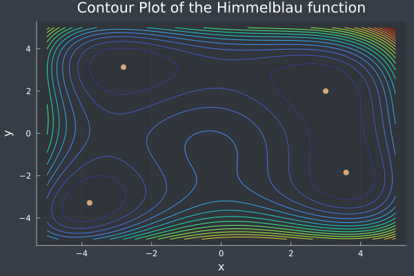

Figure 5: Contour plot of the Himmelblau function

```julia
using Plots
theme(:dark)

# Himmelblau function
f(x,y) = (x^2 + y - 11)^2 + (x + y^2 - 7)^2

x = range(-5, 5, length=100);
y = range(-5, 5, length=100);
z = @. f(x', y);

contour(x, y, z, levels=20, color=:turbo, cbar=false, lw=1)
scatter!([3.0, -2.805118, -3.779310, 3.584428], [2.0, 3.131312, -3.283186, -1.848126], legend=false)

title!("Contour Plot of the Himmelblau function")
xlabel!("x")
ylabel!("y")
```

**Solution**

Calculate the gradient:
$$\begin{aligned}
\nabla f &=
\begin{bmatrix}
2(x^2 + y - 11) 2x + 2(x + y^2 - 7) \\
2(x^2 + y - 11) + 2(x + y^2 - 7) 2y
\end{bmatrix} \\
&=
\begin{bmatrix}
4x^3 + 2y^2 + 4xy - 42x - 14 \\
4 y^3 + 2x^2 + 4xy - 26y - 22
\end{bmatrix}
\end{aligned}$$

Calculate the Hessian:
$$\begin{aligned}
H &=
\begin{bmatrix}
12x^2 + 4y - 42 & 4x + 4y \\
4x + 4y & 12y^2 + 4x - 26
\end{bmatrix}
\end{aligned}$$

Substitue $(3, 2)$ for $x$ and $y$:
$$H(3, 2) =
\begin{bmatrix}
74 & 20 \\
20 & 34
\end{bmatrix}$$

Determinte the characteristic polynomial:
$$\begin{aligned}
\det (H - \lambda I) &=
\begin{vmatrix}
74 - \lambda & 20 \\
20 & 34 - \lambda
\end{vmatrix} \\
&= (74 - \lambda) (34 - \lambda) - 20^2 \\
&= \lambda^2 - 108 \lambda + 2116 \\
&\overset{\text{!}}{=} 0
\end{aligned}$$

Solve for $\lambda$ to obtain the Eigenvalues:
$$\begin{aligned}
\lambda_1 = \frac{108}{2} - \sqrt{ \left( \frac{108}{2} \right)^2 - 2116}
\approx 25.716 \\
\lambda_2 = \frac{108}{2} + \sqrt{ \left( \frac{108}{2} \right)^2 - 2116}
\approx 82.284
\end{aligned}$$

All Eigenvalues are greater than 0, so $f$ is in (3, 2) positive definite.

Alternatively, we can also solve this using the `Symbolics` package in Julia:

- Julia
- Python + SymPy
- MATLAB/Octave
- Python + Autograd

```julia
using Symbolics
using LinearAlgebra

# Himmelblau function
f(x, y) = (x^2 + y - 11)^2 + (x + y^2 - 7)^2

vars = @variables x, y
f_sym = f(x, y)

H = Symbolics.hessian(f_sym, vars)
H_at_point = substitute.(H, Ref(Dict( x=>3.0, y=>2.0) ))

isposdef(H_at_point)
```

```python
import numpy as np
from sympy import symbols, hessian
from scipy import linalg

f = lambda x, y: (x**2 + y - 11)**2 + (x + y**2 - 7)**2

x, y = symbols("x y")
f_sym = f(x, y)

H = hessian(f_sym, (x,y))
H_at_point = np.array( H.subs( {x:3, y:2} ) )

linalg.cholesky(H_at_point)
```

```matlab
pkg load symbolic

% Himmelblau function
f = @(x, y) (x^2 + y - 11)^2 + (x + y^2 - 7)^2

syms x; syms y;

f_sym = f(x, y)
H_sym = hessian(f_sym)
H = function_handle(H_sym)
H_at_point = H(3, 2)

chol(H_at_point)
```

```python
import autograd.numpy as np
from autograd import hessian
from scipy import linalg

f = lambda X: (X[0]**2 + X[1] - 11)**2 + (X[0] + X[1]**2 - 7)**2

H = hessian(f)
point = np.array([3.0, 2.0])
H_at_point = H(point)

linalg.cholesky(H_at_point)
```

Boyd, Stephen, and Lieven Vandenberghe. 2004. *Convex Optimization*. Cambridge University Press. https://web.stanford.edu/~boyd/cvxbook/.